# Analysis of US Covid-19 Death Rates in the United States

James Roy

2023-03-01

# Overview

[output not shown]

*For clarity, we will use the term ‘Covid-19’ for all cases and deaths, when referring to the virus: SARS-CoV-2, or the disease it creates: Covid-19.*

# Data

[output not shown]

# Methods and Analysis

```
The following section comprises of the majority of our research and analysis. All the steps, deductions, and processes will be provided together with the findings and important outcomes. The presentation should be clear enough to follow and reproduce for future study.
```

*Important Libraries Used: tidyverse, lubridate, stringr*

## Step 1 Identify and Import The Data

In this step we import four main CSV files from the JHU Github Account. This is includes global data on deaths and cases, and US data on deaths and cases.

```r
library(lubridate)
library(stringr)
```

```r
# Get Current Data in the four files
# They all begin the same way

url_in <- "https://raw.githubusercontent.com/CSSEGISandData/COVID-19/master/csse_covid_19_data/csse_covid_19_time_series/"

file_names <- c("time_series_covid19_confirmed_global.csv", "time_series_covid19_deaths_global.csv", "time_series_covid19_confirmed_US.csv", "time_series_covid19_deaths_US.csv")

urls <- str_c(url_in,file_names)
```

## Step 2 Tidy and Transform The Data

In the next steps we will need to organize and transform our data for clearer understanding. Here we read the data into the following variables: global_cases, global_deaths, US_cases, and US_deaths.

```r
library(tidyverse)
global_cases <- read_csv(urls[1])
global_deaths <- read_csv(urls[2])
US_cases <- read_csv(urls[3])
US_deaths<- read_csv(urls[4])
```

After looking at the global data, we will tidy it up in order to see the colomns: date, cases, and deaths. We will also rename region and state to make it more R friendly and tidy. Then we will get rid of Lat and long.

```r
#tidy global cases

global_cases <- global_cases %>%
  pivot_longer(cols = -c(`Province/State`,`Country/Region`, Lat, Long),
               names_to = "date",
               values_to = "cases") %>%
  select(-c(Lat,Long))

#tidy global deaths

global_deaths <- global_deaths %>%
  pivot_longer(cols = -c(`Province/State`,`Country/Region`, Lat, Long),
               names_to = "date",
               values_to = "deaths") %>%
  select(-c(Lat,Long))

#combine global cases and deaths

global <- global_cases %>%
  full_join(global_deaths)  %>%
  rename(Province_State = `Province/State`,
         Country_Region = `Country/Region`) %>%
  mutate(date = mdy(date))
#returns Joining with `by = join_by(`Province/State`, `Country/Region`, date, cases)`

#go over code and make changes as necessary
summary(global)
```

```
##  Province_State     Country_Region          date                cases
##  Length:329460      Length:329460      Min.   :2020-01-22   Min.   :        0
##  Class :character   Class :character   1st Qu.:2020-11-01   1st Qu.:      674
##  Mode  :character   Mode  :character   Median :2021-08-13   Median :    14336
##                                        Mean   :2021-08-13   Mean   :   955749
##                                        3rd Qu.:2022-05-25   3rd Qu.:   227878
##                                        Max.   :2023-03-06   Max.   :103655657
##      deaths
##  Min.   :      0
##  1st Qu.:      3
##  Median :    149
##  Mean   :  13353
##  3rd Qu.:   3017
##  Max.   :1122264
```

```r
#removed where 0 cases because skew/outliers/wont be able to tell as much from deaths
global <- global %>% filter(cases>0)
summary(global)
```

```
##  Province_State     Country_Region          date                cases
##  Length:305966      Length:305966      Min.   :2020-01-22   Min.   :        1
##  Class :character   Class :character   1st Qu.:2020-12-11   1st Qu.:     1309
##  Mode  :character   Mode  :character   Median :2021-09-14   Median :    20275
##                                        Mean   :2021-09-10   Mean   :  1029137
##                                        3rd Qu.:2022-06-13   3rd Qu.:   270739
##                                        Max.   :2023-03-06   Max.   :103655657
##      deaths
##  Min.   :      0
##  1st Qu.:      7
##  Median :    213
##  Mean   :  14378
##  3rd Qu.:   3649
##  Max.   :1122264
```

```r
#check data to be valid, they are all in the US which makes sense
global %>% filter(cases>100000000)
```

```
## # A tibble: 77 × 5
##    Province_State Country_Region date           cases  deaths
##    <chr>          <chr>          <date>         <dbl>   <dbl>
##  1 <NA>           US             2022-12-20 100050707 1088434
##  2 <NA>           US             2022-12-21 100232826 1089476
##  3 <NA>           US             2022-12-22 100328970 1090072
##  4 <NA>           US             2022-12-23 100368198 1090279
##  5 <NA>           US             2022-12-24 100374720 1090301
##  6 <NA>           US             2022-12-25 100377934 1090316
##  7 <NA>           US             2022-12-26 100390363 1090345
##  8 <NA>           US             2022-12-27 100501295 1090701
##  9 <NA>           US             2022-12-28 100614639 1091691
## 10 <NA>           US             2022-12-29 100718741 1092615
## # … with 67 more rows
```

We repeat the same process with the US Data:

```r
#cleaning US deaths data

US_deaths <- US_deaths %>%
     pivot_longer(cols = -(UID:Population),
                  names_to = "date",
                  values_to = "deaths") %>%
     select(Admin2:"deaths") %>%
     mutate(date = mdy(date)) %>%
     select(-c(Lat,Long_))

#cleaning US cases data

US_cases <- US_cases %>%
          pivot_longer(cols = -(UID:Combined_Key),
                                names_to = "date",
                                values_to = "cases") %>%
          select(Admin2:"cases") %>%
          mutate(date = mdy(date)) %>%
          select(-c(Lat,Long_))

#joining US data

US <- US_cases %>%
  full_join(US_deaths)
```

[output not shown]

```r
#returns - Joining with `by = join_by(Admin2, Province_State, Country_Region, Combined_Key, date)`
```

```r
#making global have the same entries as US

global <- global  %>%
     unite("Combined_Key",
     c(Province_State, Country_Region),
 sep = ", ",
 na.rm = TRUE,
 remove = FALSE)

# need population data globally

uid_look_url <- "https://raw.githubusercontent.com/CSSEGISandData/COVID-19/master/csse_covid_19_data/UID_ISO_FIPS_LookUp_Table.csv"

#cleanup a bit

uid <- read_csv(uid_look_url) %>%
    select(-c(Lat, Long_, Combined_Key, code3, iso2, iso3, Admin2))
#still need to join data

global <- global  %>%
     left_join(uid, by = c("Province_State","Country_Region")) %>%
     select(-c(UID,FIPS)) %>%
     select(Province_State, Country_Region, date,
            cases, deaths, Population, Combined_Key)
```

## Step 3 Visualize and Analyze

Now that we have identified, organized, and confirmed the reliability of our data, we would like to start analyzing the information. First we will look at deaths per million, by state. This information can help us determine which states had higher or lower survival rates for the Covid-19 disease. The reasons for this are many. Were there better hospitals in that state? How were policies enforced? What was the proximity of living quarters? How many tests were provided? We can’t answer those questions with this dataset, but we can ask: how does the case rate impact the death rate? Then we can start to ask why.

Here we sort the data to graph:

```r
US_by_state <- US %>%
  group_by(Province_State, Country_Region, date) %>%
  summarize(cases = sum(cases), deaths = sum(deaths),
            Population = sum(Population)) %>%
  mutate(deaths_per_mill =deaths *1000000 / Population) %>%
  ungroup()
#check online to make sure population info is correct

US_totals <- US_by_state %>%
  group_by(Country_Region, date) %>%
  summarize(cases = sum(cases), deaths = sum(deaths),
            Population = sum(Population)) %>%
  mutate(deaths_per_mill =deaths *1000000 / Population) %>%
  select(Country_Region, date,
         cases, deaths, deaths_per_mill, Population) %>%
  ungroup()
#if cant see anything at beginning of data use tails to check end of data

tail(US_totals)
```

```
## # A tibble: 6 × 6
##   Country_Region date           cases  deaths deaths_per_mill Population
##   <chr>          <date>         <dbl>   <dbl>           <dbl>      <dbl>
## 1 US             2023-03-01 103522479 1120911           3367.  332875137
## 2 US             2023-03-02 103583792 1121720           3370.  332875137
## 3 US             2023-03-03 103643895 1122210           3371.  332875137
## 4 US             2023-03-04 103645827 1122217           3371.  332875137
## 5 US             2023-03-05 103647093 1122217           3371.  332875137
## 6 US             2023-03-06 103655657 1122264           3371.  332875137
```

Now we can graph the data:

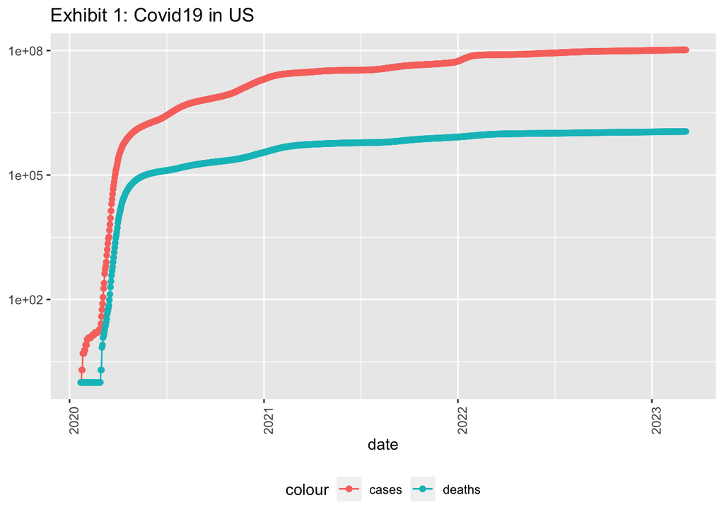

```r
#total num cases and deaths since covid reported in US

US_totals %>%
  filter(cases>0) %>%
  ggplot(aes(x = date, y = cases)) +
  geom_line(aes(color = "cases")) +
  geom_point(aes(color = "cases")) +
  geom_line(aes(y = deaths, color = "deaths")) +
  geom_point(aes(y = deaths, color = "deaths")) +
  scale_y_log10() +
  theme(legend.position = "bottom",
    axis.text.x = element_text(angle = 90)) +
  labs(title = "Exhibit 1: Covid19 in US", y= NULL)
```

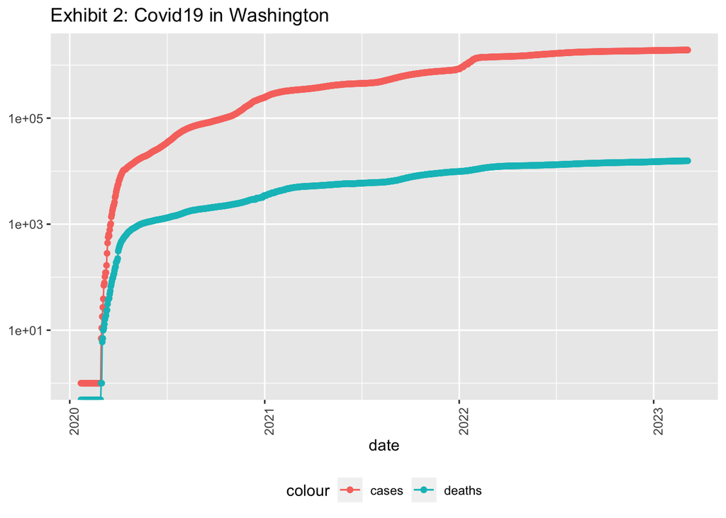

```r
#total num cases and deaths since covid reported in Washington

state <- "Washington"
US_by_state %>%
  filter(Province_State == state)  %>%
  filter(cases>0) %>%
  ggplot(aes(x = date, y = cases)) +
  geom_line(aes(color = "cases")) +
  geom_point(aes(color = "cases")) +
  geom_line(aes(y = deaths, color = "deaths")) +
  geom_point(aes(y = deaths, color = "deaths")) +
  scale_y_log10() +
  theme(legend.position = "bottom",
    axis.text.x = element_text(angle = 90)) +
  labs(title = str_c("Exhibit 2: Covid19 in ", state), y= NULL)
```

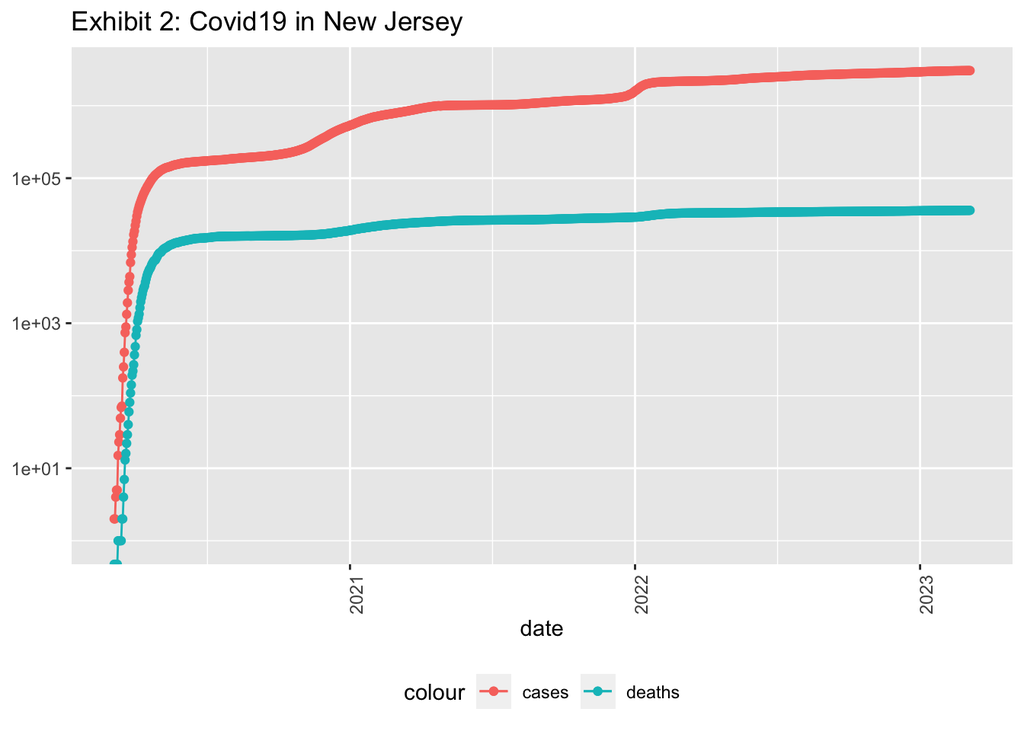

```r
#total num cases and deaths since covid reported in New Jersey

state <- "New Jersey"
US_by_state %>%
  filter(Province_State == state)  %>%
  filter(cases>0) %>%
  ggplot(aes(x = date, y = cases)) +
  geom_line(aes(color = "cases")) +
  geom_point(aes(color = "cases")) +
  geom_line(aes(y = deaths, color = "deaths")) +
  geom_point(aes(y = deaths, color = "deaths")) +
  scale_y_log10() +
  theme(legend.position = "bottom",
    axis.text.x = element_text(angle = 90)) +
  labs(title = str_c("Exhibit 2: Covid19 in ", state), y= NULL)
```

```r
# what data are we looking at?

max(US_totals$date)
```

```
## [1] "2023-03-06"
```

```r
max(US_totals$deaths)
```

```
## [1] 1122264
```

```r
#raises questions are new cases flat, have things leveled off?
#we need to analyze this
#transform data again, add new_case and add new_deaths

US_by_state <- US_by_state %>%
  mutate(new_cases = cases - lag(cases),
         new_deaths = deaths - lag(deaths))
US_totals <- US_totals %>%
  mutate(new_cases = cases - lag(cases),
         new_deaths = deaths - lag(deaths))
tail(US_totals)
```

```
## # A tibble: 6 × 8
##   Country_Region date           cases  deaths deaths_p…¹ Popul…² new_c…³ new_d…⁴
##   <chr>          <date>         <dbl>   <dbl>      <dbl>   <dbl>   <dbl>   <dbl>
## 1 US             2023-03-01 103522479 1120911      3367.  3.33e8   83376     909
## 2 US             2023-03-02 103583792 1121720      3370.  3.33e8   61313     809
## 3 US             2023-03-03 103643895 1122210      3371.  3.33e8   60103     490
## 4 US             2023-03-04 103645827 1122217      3371.  3.33e8    1932       7
## 5 US             2023-03-05 103647093 1122217      3371.  3.33e8    1266       0
## 6 US             2023-03-06 103655657 1122264      3371.  3.33e8    8564      47
## # … with abbreviated variable names ¹deaths_per_mill, ²Population, ³new_cases,
## #   ⁴new_deaths
```

```r
tail(US_totals %>% select(new_cases,new_deaths,everything()))
```

```
## # A tibble: 6 × 8
##   new_cases new_deaths Country_Region date          cases deaths death…¹ Popul…²
##       <dbl>      <dbl> <chr>          <date>        <dbl>  <dbl>   <dbl>   <dbl>
## 1     83376        909 US             2023-03-01   1.04e8 1.12e6   3367.  3.33e8
## 2     61313        809 US             2023-03-02   1.04e8 1.12e6   3370.  3.33e8
## 3     60103        490 US             2023-03-03   1.04e8 1.12e6   3371.  3.33e8
## 4      1932          7 US             2023-03-04   1.04e8 1.12e6   3371.  3.33e8
## 5      1266          0 US             2023-03-05   1.04e8 1.12e6   3371.  3.33e8
## 6      8564         47 US             2023-03-06   1.04e8 1.12e6   3371.  3.33e8
## # … with abbreviated variable names ¹deaths_per_mill, ²Population
```

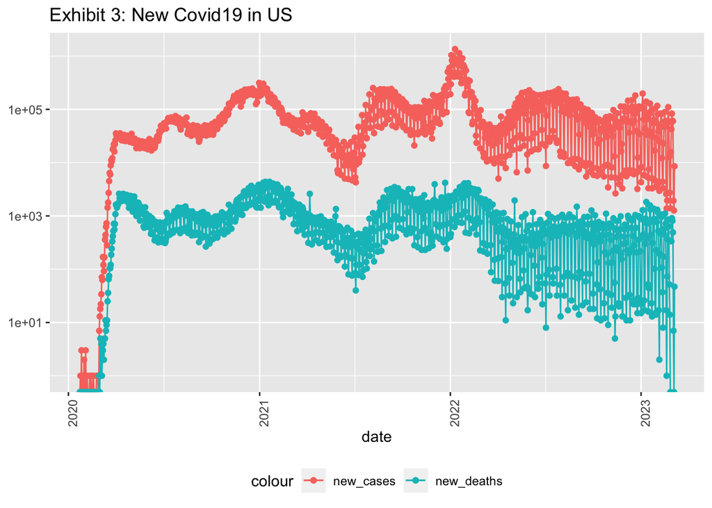

```r
### now graph new cases and new deaths in US

US_totals %>%
  filter(cases>0) %>%
  ggplot(aes(x = date, y = new_cases)) +
  geom_line(aes(color = "new_cases")) +
  geom_point(aes(color = "new_cases")) +
  geom_line(aes(y = new_deaths, color = "new_deaths")) +
  geom_point(aes(y = new_deaths, color = "new_deaths")) +
  scale_y_log10() +
  theme(legend.position = "bottom",
    axis.text.x = element_text(angle = 90)) +
  labs(title = "Exhibit 3: New Covid19 in US", y= NULL)
```

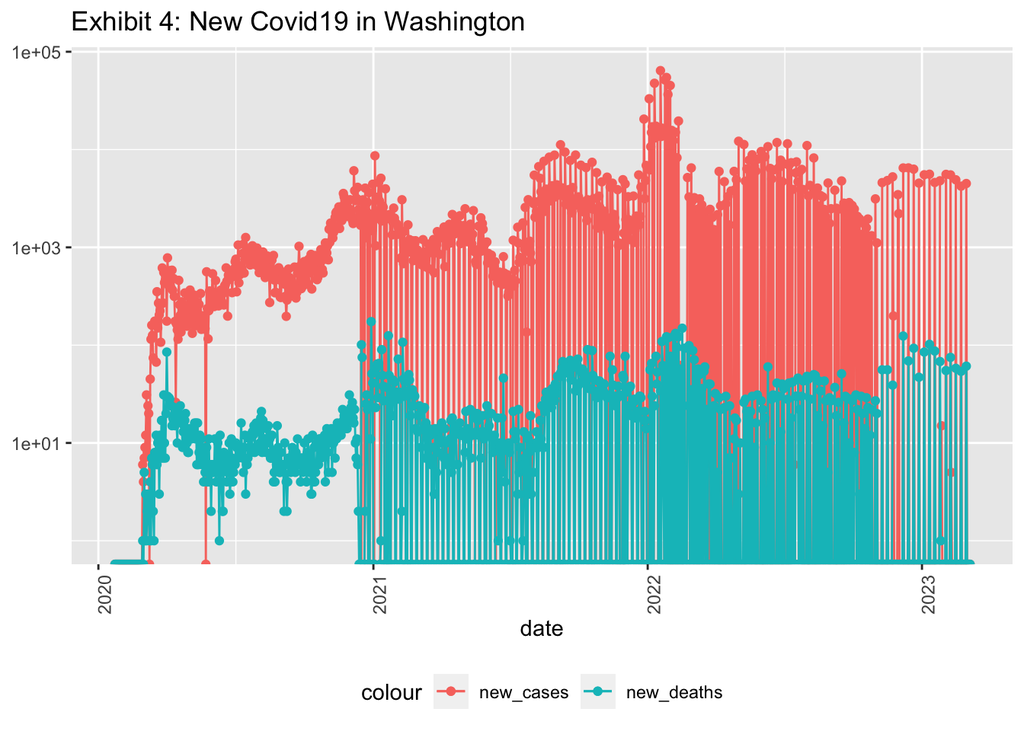

```r
### now graph Washington new cases and new deaths

state <- "Washington"
US_by_state %>%
  filter(Province_State == state)  %>%
  filter(cases>0) %>%
  ggplot(aes(x = date, y = new_cases)) +
  geom_line(aes(color = "new_cases")) +
  geom_point(aes(color = "new_cases")) +
  geom_line(aes(y = new_deaths, color = "new_deaths")) +
  geom_point(aes(y = new_deaths, color = "new_deaths")) +
  scale_y_log10() +
  theme(legend.position = "bottom",
    axis.text.x = element_text(angle = 90)) +
  labs(title = str_c("Exhibit 4: New Covid19 in ", state), y= NULL)
```

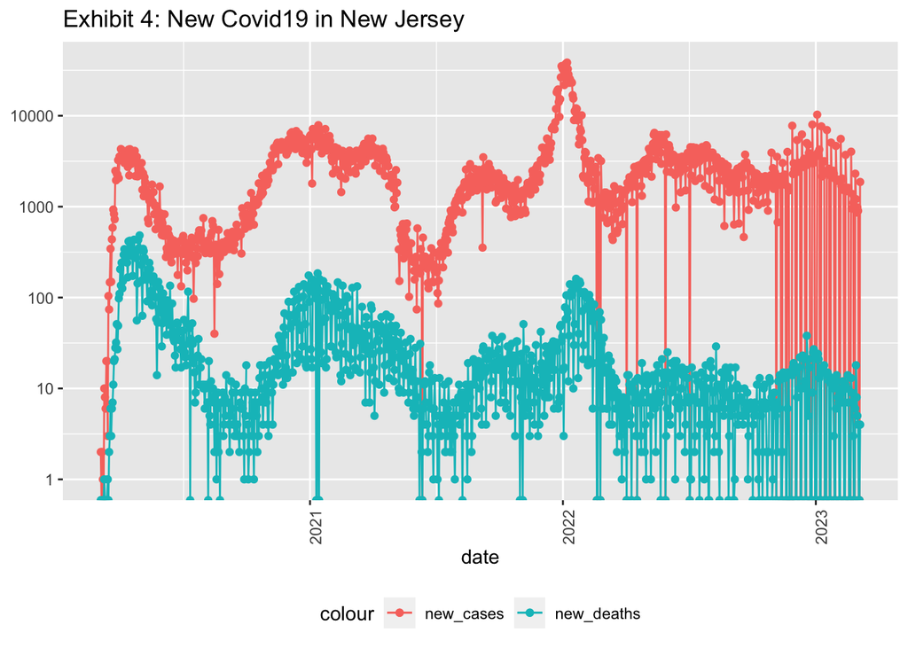

```r
### now graph New Jersey new cases and new deaths

state <- "New Jersey"
US_by_state %>%
  filter(Province_State == state)  %>%
  filter(cases>0) %>%
  ggplot(aes(x = date, y = new_cases)) +
  geom_line(aes(color = "new_cases")) +
  geom_point(aes(color = "new_cases")) +
  geom_line(aes(y = new_deaths, color = "new_deaths")) +
  geom_point(aes(y = new_deaths, color = "new_deaths")) +
  scale_y_log10() +
  theme(legend.position = "bottom",
    axis.text.x = element_text(angle = 90)) +
  labs(title = str_c("Exhibit 4: New Covid19 in ", state), y= NULL)
```

```r
###comparing state totals to see which was the best, so now we do deaths per thousand cases

US_state_totals <- US_by_state %>%
  group_by(Province_State) %>%
  summarize(deaths = max(deaths), cases = max(cases),
            population = max(Population),
            cases_per_thou = 1000 * cases / population,
            deaths_per_thou = 1000 * deaths / population) %>%
  filter(cases > 0, population > 0)

#10 states with smallest deaths per thousand

US_state_totals %>%
  slice_min(deaths_per_thou, n = 10)  %>%
#removing population
select(deaths_per_thou,cases_per_thou,everything())
```

```
## # A tibble: 10 × 6
##    deaths_per_thou cases_per_thou Province_State           deaths  cases popul…¹
##              <dbl>          <dbl> <chr>                     <dbl>  <dbl>   <dbl>
##  1           0.611           150. American Samoa               34 8.32e3   55641
##  2           0.744           248. Northern Mariana Islands     41 1.37e4   55144
##  3           1.21            231. Virgin Islands              130 2.48e4  107268
##  4           1.30            268. Hawaii                     1834 3.80e5 1415872
##  5           1.46            243. Vermont                     910 1.51e5  623989
##  6           1.55            293. Puerto Rico                5810 1.10e6 3754939
##  7           1.65            340. Utah                       5287 1.09e6 3205958
##  8           2.01            414. Alaska                     1486 3.07e5  740995
##  9           2.03            252. District of Columbia       1430 1.78e5  705749
## 10           2.06            253. Washington                15683 1.93e6 7614893
## # … with abbreviated variable name ¹population
```

```r
#10 Worst states with largest deaths per thousands

US_state_totals %>%
  slice_max(deaths_per_thou, n = 10)  %>%
#removing population
select(deaths_per_thou,cases_per_thou,everything())
```

```
## # A tibble: 10 × 6
##    deaths_per_thou cases_per_thou Province_State deaths   cases population
##              <dbl>          <dbl> <chr>           <dbl>   <dbl>      <dbl>
##  1            4.54           335. Arizona         33076 2440294    7278717
##  2            4.53           325. Oklahoma        17940 1287378    3956971
##  3            4.49           332. Mississippi     13351  989282    2976149
##  4            4.44           359. West Virginia    7960  642760    1792147
##  5            4.32           320. New Mexico       9054  670301    2096829
##  6            4.31           333. Arkansas        13001 1005930    3017804
##  7            4.28           335. Alabama         21001 1642062    4903185
##  8            4.28           368. Tennessee       29225 2510002    6829174
##  9            4.22           306. Michigan        42096 3057222    9986857
## 10            4.05           343. New Jersey      35995 3046838    8882190
```

To determine if case rate implies death rate, we created a linear model as follows:

```r
  #linear model
mod <- lm(deaths_per_thou ~ cases_per_thou, data = US_state_totals)

summary(mod)
```

```
##
## Call:
## lm(formula = deaths_per_thou ~ cases_per_thou, data = US_state_totals)
##
## Residuals:
##     Min      1Q  Median      3Q     Max
## -2.3267 -0.5992  0.1470  0.6554  1.2107
##
## Coefficients:
##                Estimate Std. Error t value Pr(>|t|)
## (Intercept)    -0.36304    0.72369  -0.502    0.618
## cases_per_thou  0.01133    0.00232   4.883 9.69e-06 ***
## ---
## Signif. codes:  0 '***' 0.001 '**' 0.01 '*' 0.05 '.' 0.1 ' ' 1
##
## Residual standard error: 0.8611 on 54 degrees of freedom
## Multiple R-squared:  0.3063, Adjusted R-squared:  0.2935
## F-statistic: 23.84 on 1 and 54 DF,  p-value: 9.685e-06
```

```r
### View Predicted Table

US_state_totals %>% mutate(pred = predict(mod))
```

```
## # A tibble: 56 × 7
##    Province_State       deaths    cases population cases_per_thou deaths…¹  pred
##    <chr>                 <dbl>    <dbl>      <dbl>          <dbl>    <dbl> <dbl>
##  1 Alabama               21001  1642062    4903185           335.    4.28   3.43
##  2 Alaska                 1486   307073     740995           414.    2.01   4.33
##  3 American Samoa           34     8320      55641           150.    0.611  1.33
##  4 Arizona               33076  2440294    7278717           335.    4.54   3.44
##  5 Arkansas              13001  1005930    3017804           333.    4.31   3.41
##  6 California           101037 12110297   39512223           306.    2.56   3.11
##  7 Colorado              14127  1763574    5758736           306.    2.45   3.11
##  8 Connecticut           12196   976156    3565287           274.    3.42   2.74
##  9 Delaware               3324   330793     973764           340.    3.41   3.49
## 10 District of Columbia   1430   177714     705749           252.    2.03   2.49
## # … with 46 more rows, and abbreviated variable name ¹deaths_per_thou
```

```r
US_tot_w_pred <- US_state_totals %>% mutate(pred = predict(mod))
US_tot_w_pred
```

```
## # A tibble: 56 × 7
##    Province_State       deaths    cases population cases_per_thou deaths…¹  pred
##    <chr>                 <dbl>    <dbl>      <dbl>          <dbl>    <dbl> <dbl>
##  1 Alabama               21001  1642062    4903185           335.    4.28   3.43
##  2 Alaska                 1486   307073     740995           414.    2.01   4.33
##  3 American Samoa           34     8320      55641           150.    0.611  1.33
##  4 Arizona               33076  2440294    7278717           335.    4.54   3.44
##  5 Arkansas              13001  1005930    3017804           333.    4.31   3.41
##  6 California           101037 12110297   39512223           306.    2.56   3.11
##  7 Colorado              14127  1763574    5758736           306.    2.45   3.11
##  8 Connecticut           12196   976156    3565287           274.    3.42   2.74
##  9 Delaware               3324   330793     973764           340.    3.41   3.49
## 10 District of Columbia   1430   177714     705749           252.    2.03   2.49
## # … with 46 more rows, and abbreviated variable name ¹deaths_per_thou
```

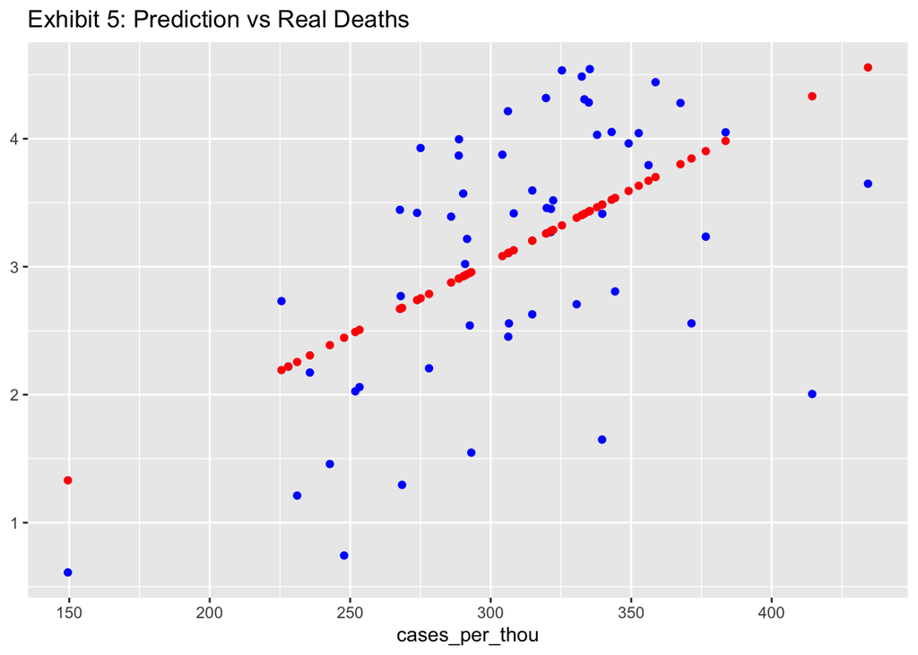

```r
### Plot Predicted vs Real deaths per thousand

US_tot_w_pred %>% ggplot() +
geom_point(aes(x = cases_per_thou, y = deaths_per_thou), color = "blue") +
geom_point(aes(x = cases_per_thou, y = pred), color = "red") +
labs(title = "Exhibit 5: Prediction vs Real Deaths ", y= NULL)
```

# Step 4 Analysis and Conclusion

**Exhibit 1: Covid19 in the US**

In this graph, we showcase the total cases and total deaths from Covid-19 in the US. We see a rapid rise when the pandemic started, and then the curve seems to flatten off. The cases appear to correlate with the deaths.

**Exhibit 2: Covid19 in the Washington and New Jersey**

The same graph as before, but by state. Here we confirm that the US graph correlates to the State Graphs, as would be expected. Washington is in the top 10 performers list, when it comes to deaths by population. New Jersey is in the bottom 10. Both states have similar populations, dense metropolitan areas, and similar coastal temperatures, allowing for better comparison.

**Exhibit 3: New Covid19 in the US**

The previous graph showed accumulating case and death data. Now we look at the daily rise or decline in cases and deaths, from new case/new death data.

**Exhibit 4: Covid19 in the Washington and New Jersey**

Once again, we see that the trends in each state generally coincide with the US data as a whole.

**Exhibit 5: Prediction vs Real Deaths**

In the final graph, we established a linear model to represent how the number of cases affects the number of deaths. There is a clear trend associated with increasing cases and increasing deaths, however, there are a significant amount of outliers.

## Final Summary

[output not shown]

## Future Research

[output not shown]